# Baseline Nowcast Evaluation: Flu NSSP

## Triangle Plot

```r
# Final values (most recent version per reference week)
triangle_df <- as.data.frame(rep_tri) |>
  mutate(time = as.numeric(factor(reference_date)))

plot_triangle <- ggplot(
  triangle_df,
  aes(x = delay, y = time, fill = count)
) +
  geom_tile() +
  scale_fill_gradient(low = "white", high = "blue") +
  labs(title = "Reporting triangle", x = "Delay", y = "Time") +
  theme_bw() +
  scale_y_reverse()
```

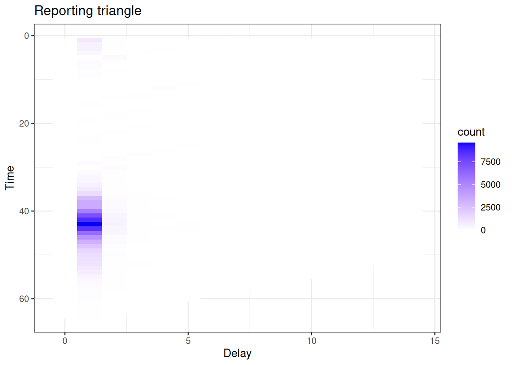

```r
plot_triangle
```

# Retrospective Evaluation

To evaluate how well `baselinenowcast` would have performed in practice, we re-run it at every weekly version date in the archive, for every state/territory. Each call receives only the data that would have been available at that point in time — no future information leaks in.

Results are restricted to the 7 reference weeks closest to each nowcast date (`eval_window_weeks = 7`), which covers the range where real-time revision uncertainty is highest.

## Actually running

```r
retro_nowcast_dates <- seq(
  from = min(nssp_archive$DT$version),
  to = max(nssp_archive$DT$version),
  by = "1 week"
)

min_version <- min(nssp_archive$DT$version)
retro_nowcast_dates <- retro_nowcast_dates[retro_nowcast_dates >= min_version + 10 * 7]

cat("Running retrospective nowcasts for", length(retro_nowcast_dates), "dates\n")
```

```
Running retrospective nowcasts for 98 dates
```

This next block is the bulk of the retro forecasting code; `run_retro_nowcast` fits baselinenowcast on a single `nowcast_date` and `geo_value`. Note that this is using parallelism via `furrr::future_pmap`.

```r
run_retro_nowcast <- function(nowcast_date, incremental_data, geo,
                              truncate_quantile = 0.99, draws = 500L, eval_window_weeks = 7L) {
  long_data <- incremental_data |>
    filter(geo_value == geo, report_date <= nowcast_date) |>
    select(-geo_value)

  has_negatives <- any(long_data$count < 0)

  rep_tri_trunc <- tryCatch(
    suppressMessages(
      as_reporting_triangle(long_data, delays_unit = "weeks") |>
        truncate_to_quantile(truncate_quantile)
    ),
    error = function(e) {NULL}
  )
  if (is.null(rep_tri_trunc) || nrow(as.data.frame(rep_tri_trunc)) == 0) return(NULL)

  set.seed(as.integer(nowcast_date))
  draws_df <- tryCatch(
    baselinenowcast(rep_tri_trunc, scale_factor = 3, prop_delay = 0.5, draws = draws),
    error = function(e) {NULL})
  if (is.null(draws_df)) return(NULL)

  draws_df |>
    filter(nowcast_date - reference_date < eval_window_weeks * 7) |>
    group_by(reference_date) |>
    summarise(
      median = median(pred_count),
      q05 = quantile(pred_count, 0.05),
      q25 = quantile(pred_count, 0.25),
      q75 = quantile(pred_count, 0.75),
      q95 = quantile(pred_count, 0.95)
    ) |>
    mutate(nowcast_date = nowcast_date, geo_value = geo, has_negatives = has_negatives)
}


geo_values <- unique(nssp_archive$DT$geo_value)

retro_grid <- tidyr::expand_grid(
  nowcast_date = retro_nowcast_dates,
  geo = geo_values
)

plan(multisession, workers = parallel::detectCores() - 1)
retro_nowcasts <- furrr::future_pmap(
  retro_grid,
  run_retro_nowcast,
  incremental_data = incremental_data,
  .options = furrr_options(seed = TRUE)
) |>
  purrr::compact() |>
  bind_rows() |>
  mutate(across(c(median, q05, q25, q75, q95), ~ .x / 1000))
plan(sequential)

cat("Total nowcast dates to evaluate:", nrow(retro_nowcasts), "\n")
```

```
Total nowcast dates to evaluate: 26329
```

```r
cat("Reference dates covered:", n_distinct(retro_nowcasts$reference_date), "\n")
```

```
Reference dates covered: 101
```

## WIS Scoring

Nowcasts are scored against the most recent available version of each reference week’s count, which we treat as ground truth. Scores are computed using `scoringutils::score()` on the five quantile levels (5th, 25th, 50th, 75th, 95th) returned by the nowcaster.

The naive baseline is the absolute error of the as-of value - i.e. what you’d get by simply reporting the current value without any nowcast adjustment. Cases where the naive baseline is `NA` (the as-of snapshot had no value for that reference date) are dropped. Cases where the naive WIS would be zero — meaning the as-of value already matched the final value exactly — are retained, since excluding them would make the nowcaster look artificially better.

```r
final_values_retro <- nssp_archive |>
  epix_as_of_current() |>
  select(geo_value, reference_date = time_value, final_value = value)

calc_naive_wis <- function(as_of_date) {
  nssp_archive |>
    epix_as_of(as_of_date) |>
    rename(reference_date = time_value, as_of_value = value) |>
    left_join(final_values_retro, by = join_by(geo_value, reference_date)) |>
    mutate(nowcast_date = as_of_date, naive_wis = abs(as_of_value - final_value)) |>
    select(geo_value, nowcast_date, reference_date, as_of_value, naive_wis)
}
naive_wis <- map(retro_nowcasts$nowcast_date |> unique(), calc_naive_wis) |> list_rbind()

scores <- retro_nowcasts |>
  left_join(final_values_retro, by = join_by(geo_value, reference_date)) |>
  filter(!is.na(final_value)) |>
  pivot_longer(
    cols = c(q05, q25, median, q75, q95),
    names_to = "quantile_level",
    values_to = "predicted"
  ) |>
  mutate(
    quantile_level = case_match(
      quantile_level,
      "q05" ~ 0.05, "q25" ~ 0.25, "median" ~ 0.5, "q75" ~ 0.75, "q95" ~ 0.95
    ),
    model = "baselinenowcast"
  ) |>
  rename(observed = final_value) |>
  as_forecast_quantile(
    forecast_unit = c("model", "nowcast_date", "reference_date", "geo_value"),
    observed = "observed",
    predicted = "predicted",
    quantile_level = "quantile_level"
  ) |>
  score() |>
  left_join(naive_wis, by = join_by(geo_value, nowcast_date, reference_date)) |>
  filter(!is.na(naive_wis)) |>
  mutate(
    relative_wis = wis / naive_wis,
    horizon_weeks = difftime(nowcast_date, reference_date, units = "weeks")
  )

scores |>
  summarise(
    skill = round(1 - mean(wis) / mean(naive_wis), 3),
    mean_wis = round(mean(wis), 2),
    mean_naive_wis = round(mean(naive_wis), 2),
    across(c(overprediction, underprediction, dispersion), ~ round(mean(.x), 2))
  )
```

```
     skill mean_wis mean_naive_wis overprediction underprediction dispersion
1 -941.214    22.18           0.02           0.24            0.01      21.93
```

```r
scored_better <- scores |> filter(wis < naive_wis)

cat(sprintf(
  "Nowcast beats naive: %d of %d scored instances (%.1f%%)\n",
  nrow(scored_better),
  nrow(scores),
  100 * nrow(scored_better) / nrow(scores)
))
```

```
Nowcast beats naive: 7020 of 26317 scored instances (26.7%)
```

### Score by horizon

```r
scores |>
  group_by(horizon_weeks) |>
  summarise(
    percent_nowcast_better = round(100 * mean(wis < naive_wis), 1),
    skill_when_better = round(
      1 - mean(wis[wis < naive_wis]) / mean(naive_wis[wis < naive_wis]),
      3
    ),
    n = n(),
    .groups = "drop"
  )
```

```
# A tibble: 6 × 4
  horizon_weeks percent_nowcast_better skill_when_better     n
  <drtn>                         <dbl>             <dbl> <int>
1 1 weeks                         53.4             0.486  3859
2 2 weeks                         34.2             0.471  4144
3 3 weeks                         25.2             0.448  4384
4 4 weeks                         21.2             0.413  4529
5 5 weeks                         17.4             0.362  4675
6 6 weeks                         14               0.311  4726
```

#### Skill Score

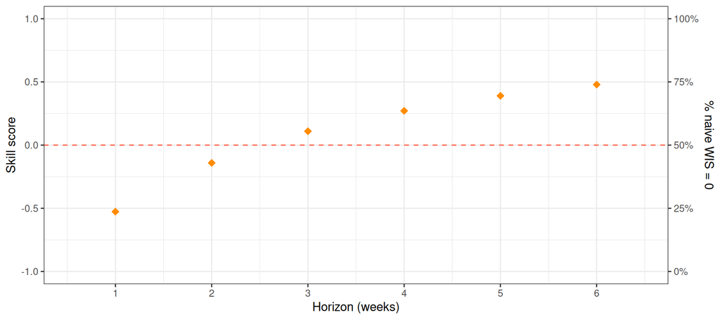

```r
scores |>
  filter(geo_value %nin% c("vi", "as", "gu")) |>
  group_by(horizon_weeks) |>
  summarise(
    skill = 1 - mean(wis) / mean(naive_wis),
    pct_naive_zero = mean(naive_wis == 0),
    n = n()
  ) |>
  ggplot(aes(horizon_weeks)) +
  geom_col(aes(y = skill)) +
  geom_hline(yintercept = 0, linetype = "dashed", colour = "tomato") +
  geom_point(aes(y = 2 * pct_naive_zero - 1), colour = "darkorange", size = 3, shape = 18) +
  scale_x_continuous(breaks = \(x) seq(floor(min(x)), ceiling(max(x)))) +
  scale_y_continuous(
    limits = c(-1, 1),
    sec.axis = sec_axis(~ (. + 1) / 2, name = "% naive WIS = 0", labels = scales::percent)
  ) +
  labs(x = "Horizon (weeks)", y = "Skill score")
```

#### Absolute improvement

One way of getting around the zero value problem is looking at the average absolute improvement.

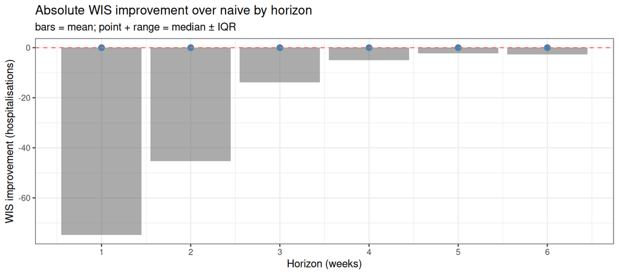

```r
scores |>
  filter(geo_value %nin% c("vi", "as", "gu")) |>
  group_by(horizon_weeks) |>
  summarise(
    mean_improvement = mean(naive_wis - wis),
    median_improvement = median(naive_wis - wis),
    q25_improvement = quantile(naive_wis - wis, 0.25),
    q75_improvement = quantile(naive_wis - wis, 0.75),
    n = n()
  ) |>
  ggplot(aes(horizon_weeks)) +
  geom_col(aes(y = mean_improvement), alpha = 0.5) +
  geom_pointrange(
    aes(y = median_improvement, ymin = q25_improvement, ymax = q75_improvement),
    colour = "steelblue", size = 0.5
  ) +
  geom_hline(yintercept = 0, linetype = "dashed", colour = "tomato") +
  scale_x_continuous(breaks = \(x) seq(floor(min(x)), ceiling(max(x)))) +
  labs(title = "Absolute WIS improvement over naive by horizon",
       subtitle = "bars = mean; point + range = median ± IQR",
       x = "Horizon (weeks)", y = "WIS improvement (hospitalisations)")
```

Which appears to be dominated by outliers.